# Task 4. HW

Maria Bochkareva

2023-11-11

# Сравнение вероятностей наступления события в двухгрупповом исследовании

## 1. Модель пациента

```r
p_R <- 0.1 # Истинная вероятность выздоровления для референса (в ГЕНЕРАЛЬНОЙ СОВОКУПНОСТИ)
p_T <- 0.2 # Истинная вероятность выздоровления для теста (в ГЕНЕРАЛЬНОЙ СОВОКУПНОСТИ)
true_OR <- (p_T/(1-p_T))/(p_R/(1-p_R)) # Истинное отношение шансов
```

## 2. Генерация однократной выборки

```r
sample_size <- 100 # Количество пациентов в каждой из групп
df_trial <- data.frame(
  arm = rep(c('R', 'T'), each = sample_size),
  patient_ID = rep(1:sample_size, 2),
  recovery_status = c(sample(c(1,0), sample_size, replace = TRUE, prob = c(p_R, 1 - p_R)),
                      sample(c(1,0), sample_size, replace = TRUE, prob = c(p_T, 1 - p_T)))
)
```

## 3. Построение ДИ для разницы вероятностей

```r
df_prop <- df_trial %>%
  group_by(arm) %>% # Группировка по типу интервенции (тест/референс)
  dplyr::summarise(x = sum(recovery_status), # Подсчет числа положительных исходов
                   n = n()) %>% # Подсчет общего числа пациентов в группе
  ungroup() %>%
  dplyr::summarise(X = list(x), N = list(n)) %>% # Соединение все x и n в отдельные вектора
  rowwise() %>%
  mutate(tst = list(broom::tidy(prop.test(X, N)))) %>% # Вычисление ДИ на разницу пропорций
  unnest(tst) %>% # Раскладка результатов prop.test по столбцам
  mutate(catch = ifelse(conf.low < p_R-p_T & p_R-p_T < conf.high, "Catch", "Miss"))

print(df_prop)
```

```
## # A tibble: 1 × 12
##   X     N     estimate1 estimate2 statistic p.value parameter conf.low conf.high
##   <lis> <lis>     <dbl>     <dbl>     <dbl>   <dbl>     <dbl>    <dbl>     <dbl>
## 1 <dbl> <int>      0.09      0.16      1.65   0.200         1   -0.171    0.0312
## # ℹ 3 more variables: method <chr>, alternative <chr>, catch <chr>
```

## ЗАДАНИЕ №1

- Повторить этот эксперимент 1000 раз, каждый раз фиксируя факт накрытия истинной разницы в вероятностях (p_R-p_T):

```r
count_catch <- 0 #Устанавливаем начальное значение счетчика
num_simulations <- 1000 #Количество повторений эксперимента

#Генерация однократной выборки

for (i in 1:num_simulations) {
  sample_size <- 100
  df_trial <- data.frame(
    arm = rep(c('R', 'T'), each = sample_size),
    patient_ID = rep(1:sample_size, 2),
    recovery_status = c(sample(c(1, 0), sample_size, replace = TRUE, prob = c(p_R, 1 - p_R)),
                        sample(c(1, 0), sample_size, replace = TRUE, prob = c(p_T, 1 - p_T)))
  )

#Построение ДИ для разницы вероятностей

  df_prop <- df_trial %>%
    group_by(arm) %>%
    dplyr::summarise(x = sum(recovery_status),
                     n = n()) %>%
    ungroup() %>%
    dplyr::summarise(X = list(x), N = list(n)) %>%
    rowwise() %>%
    mutate(tst = list(broom::tidy(prop.test(X, N)))) %>%
    unnest(tst) %>%
    mutate(catch = ifelse(conf.low < p_R - p_T & p_R - p_T < conf.high, "Catch", "Miss"))

#Проверка, попадает ли разница в заданный диапазон

  if ("Catch" %in% df_prop$catch) {
    count_catch <- count_catch + 1
  }
}

#Вывод результатов

cat("Количество раз, когда разница попала в заданный диапазон:", count_catch, "\n")
```

```
## Количество раз, когда разница попала в заданный диапазон: 955
```

```r
cat("Доля успешных экспериментов:", count_catch / num_simulations, "\n")
```

```
## Доля успешных экспериментов: 0.955
```

- Оценить полученную вероятность накрытия с заданной по умолчанию (0.95):

```r
#Заданная вероятность накрытия

expected_coverage <- 0.95

#Расчет полученной вероятности накрытия

observed_coverage <- count_catch / num_simulations

#Вывод результатов

cat("Ожидаемая вероятность накрытия:", expected_coverage, "\n")
```

```
## Ожидаемая вероятность накрытия: 0.95
```

```r
cat("Полученная вероятность накрытия:", observed_coverage, "\n")
```

```
## Полученная вероятность накрытия: 0.955
```

```r
cat("Разница:", abs(expected_coverage - observed_coverage), "\n")
```

```
## Разница: 0.005
```

- Построить гистограмму точечной оценки разницы вероятностей (estimate1-estimae2) и подумать о ее распределении:

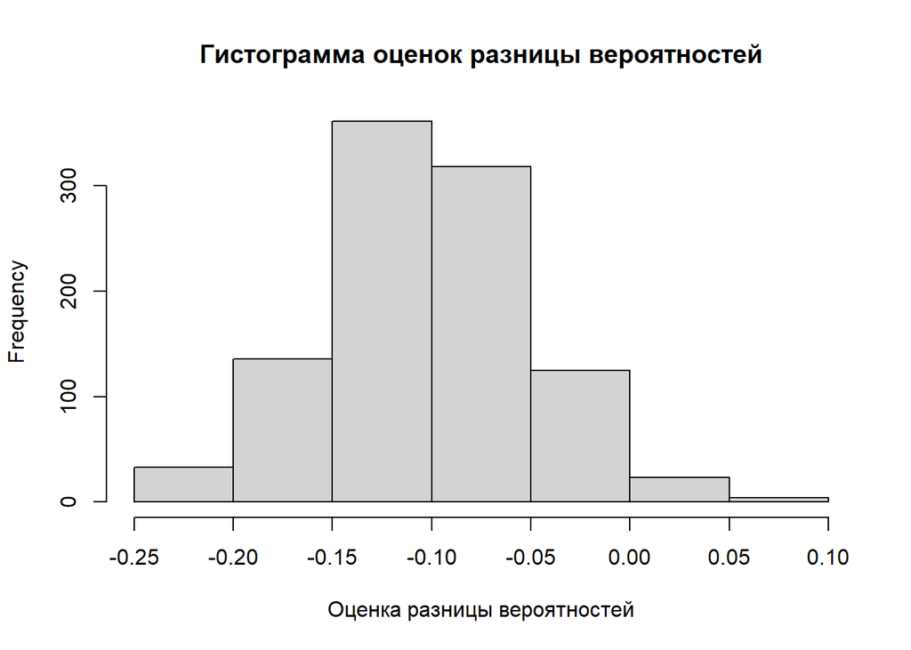

```r
difference_estimates <- numeric(num_simulations) #Создание вектора для хранения оценок разницы вероятностей

for (i in 1:num_simulations) {
  #Генерация однократной выборки
  sample_size <- 100
  df_trial <- data.frame(
    arm = rep(c('R', 'T'), each = sample_size),
    patient_ID = rep(1:sample_size, 2),
    recovery_status = c(sample(c(1, 0), sample_size, replace = TRUE, prob = c(p_R, 1 - p_R)),
                        sample(c(1, 0), sample_size, replace = TRUE, prob = c(p_T, 1 - p_T)))
  )

  # Построение ДИ для разницы вероятностей

  df_prop <- df_trial %>%
    group_by(arm) %>%
    dplyr::summarise(x = sum(recovery_status),
                     n = n())

  # Вычисление оценки разницы вероятностей

  estimate1 <- df_prop$x[df_prop$arm == "R"] / df_prop$n[df_prop$arm == "R"]
  estimate2 <- df_prop$x[df_prop$arm == "T"] / df_prop$n[df_prop$arm == "T"]
  difference_estimates[i] <- estimate1 - estimate2
}

# Построение гистограммы оценок разницы вероятностей

hist(difference_estimates, main = "Гистограмма оценок разницы вероятностей", xlab = "Оценка разницы вероятностей")
```

- Проверить, корректно ли работает методика построения ДИ, реализованная в prop.test, при различных значениях p_R и p_T:

```r
# Функция для проверки покрытия истинных вероятностей ДИ
check_coverage <- function(p_R, p_T, num_simulations) {
  count_catch <- 0 # счетчик попаданий истинного значения в ДИ

  for (i in 1:num_simulations) {
    # Генерация выборки
    sample_size <- 100
    df_trial <- data.frame(
      arm = rep(c('R', 'T'), each = sample_size),
      patient_ID = rep(1:sample_size, 2),
      recovery_status = c(sample(c(1, 0), sample_size, replace = TRUE, prob = c(p_R, 1 - p_R)),
                          sample(c(1, 0), sample_size, replace = TRUE, prob = c(p_T, 1 - p_T)))
    )

    # Построение ДИ для разницы вероятностей
    df_prop <- df_trial %>%
      group_by(arm) %>%
      summarise(x = sum(recovery_status), n = n()) %>%
      ungroup() %>%
      summarise(X = list(x), N = list(n)) %>%
      rowwise() %>%
      mutate(tst = list(broom::tidy(prop.test(X, N)))) %>%
      unnest(tst) %>%
      mutate(catch = ifelse(conf.low < p_R - p_T & p_R - p_T < conf.high, TRUE, FALSE))

    # Обновление счетчика
    if (any(df_prop$catch)) {
      count_catch <- count_catch + 1
    }
  }

  # Возвращаем долю попаданий
  return(count_catch / num_simulations)
}

# Тестируем различные значения p_R и p_T
set.seed(123) # Для воспроизводимости результатов
p_values <- seq(0.0, 1.0, by = 0.1)
coverage_results <- outer(p_values, p_values, Vectorize(check_coverage, vectorize.args = c("p_R", "p_T")), num_simulations = 50)

# Смотрим результаты
print(coverage_results)
```

```
##       [,1] [,2] [,3] [,4] [,5] [,6] [,7] [,8] [,9] [,10] [,11]
##  [1,] 0.00 1.00 0.94 0.94 0.94 0.98 0.96 0.98 0.96  0.96  0.00
##  [2,] 0.96 0.96 1.00 0.92 0.96 1.00 0.98 0.98 0.98  0.98  0.98
##  [3,] 1.00 0.92 0.96 0.98 0.98 0.96 0.98 0.98 0.94  0.96  0.98
##  [4,] 0.94 1.00 0.90 0.92 0.98 1.00 0.94 0.96 0.96  0.92  0.98
##  [5,] 0.98 0.94 0.94 0.96 0.98 0.98 0.98 0.98 0.96  0.98  0.98
##  [6,] 0.98 0.92 0.96 1.00 0.98 0.96 1.00 0.92 0.92  0.98  0.94
##  [7,] 0.96 0.98 0.96 0.90 1.00 0.98 0.96 0.98 0.96  0.94  0.98
##  [8,] 0.96 0.94 1.00 0.98 0.96 0.94 0.96 0.96 0.98  0.96  1.00
##  [9,] 0.98 1.00 0.98 0.98 0.96 0.96 0.98 0.98 0.98  0.96  0.92
## [10,] 1.00 0.96 0.94 0.94 0.96 0.94 0.98 0.96 0.96  0.98  0.96
## [11,] 0.00 1.00 0.94 1.00 0.96 0.96 0.94 1.00 0.96  0.96  0.00
```

Эти результаты показывают долю случаев, когда истинная разница вероятностей попадала в доверительный интервал, построенный с помощью prop.test для 50 симуляций на каждую пару значений.

## 4. Построение ДИ для отношения шансов

```r
df_OR <- df_trial %>%
  dplyr::summarise(broom::tidy(fisher.test(table(.$arm, .$recovery_status)))) %>%
  mutate(catch = ifelse(conf.low < true_OR & true_OR < conf.high, "Catch", "Miss"))

print(df_OR)
```

```
##   estimate    p.value conf.low conf.high                             method
## 1 3.414593 0.00556769 1.378094  9.349412 Fisher's Exact Test for Count Data
##   alternative catch
## 1   two.sided Catch
```

## ЗАДАНИЕ №2

- Повторить этот эксперимент 1000 раз, каждый раз фиксируя факт накрытия истинного отношения шансов (true_OR):

```r
count_catch_OR <- 0  #Устанавливаем начальное значение счетчика
num_simulations <- 1000 #Количество повторений эксперимента

#Генерация однократной выборки

for (i in 1:num_simulations) {
  sample_size <- 100
  df_trial <- data.frame(
    arm = rep(c('R', 'T'), each = sample_size),
    patient_ID = rep(1:sample_size, 2),
    recovery_status = c(sample(c(1, 0), sample_size, replace = TRUE, prob = c(p_R, 1 - p_R)),
                        sample(c(1, 0), sample_size, replace = TRUE, prob = c(p_T, 1 - p_T)))
  )

#Построение ДИ для отношения шансов

  df_OR <- df_trial %>%
    dplyr::summarise(broom::tidy(fisher.test(table(.$arm, .$recovery_status)))) %>%
    mutate(catch = ifelse(conf.low < true_OR & true_OR < conf.high, "Catch", "Miss"))

  #Проверка, попадает ли отношение шансов в заданный диапазон

  if ("Catch" %in% df_OR$catch) {
    count_catch_OR <- count_catch_OR + 1
  }
}

#Вывод результатов

cat("Количество раз, когда отношение шансов попало в заданный диапазон:", count_catch_OR, "\n")
```

```
## Количество раз, когда отношение шансов попало в заданный диапазон: 972
```

```r
cat("Доля успешных экспериментов для отношения шансов:", count_catch_OR / num_simulations, "\n")
```

```
## Доля успешных экспериментов для отношения шансов: 0.972
```

- Оценить полученную вероятность накрытия с заданной по умолчанию (0.95).

```r
observed_coverage <- count_catch_OR / num_simulations #оценка полученной вероятности накрытия
expected_coverage <- 0.95 #заданная вероятность накрытия

#Вывод результатов

cat("Ожидаемая вероятность накрытия: ", expected_coverage, "\n")
```

```
## Ожидаемая вероятность накрытия:  0.95
```

```r
cat("Наблюдаемая вероятность накрытия: ", observed_coverage, "\n")
```

```
## Наблюдаемая вероятность накрытия:  0.972
```

```r
cat("Разница между наблюдаемой и ожидаемой вероятностью накрытия: ", abs(observed_coverage - expected_coverage), "\n")
```

```
## Разница между наблюдаемой и ожидаемой вероятностью накрытия:  0.022
```

- Построить гистограмму точечной оценки отношения шансов (estimate) и подумать о ее распределении:

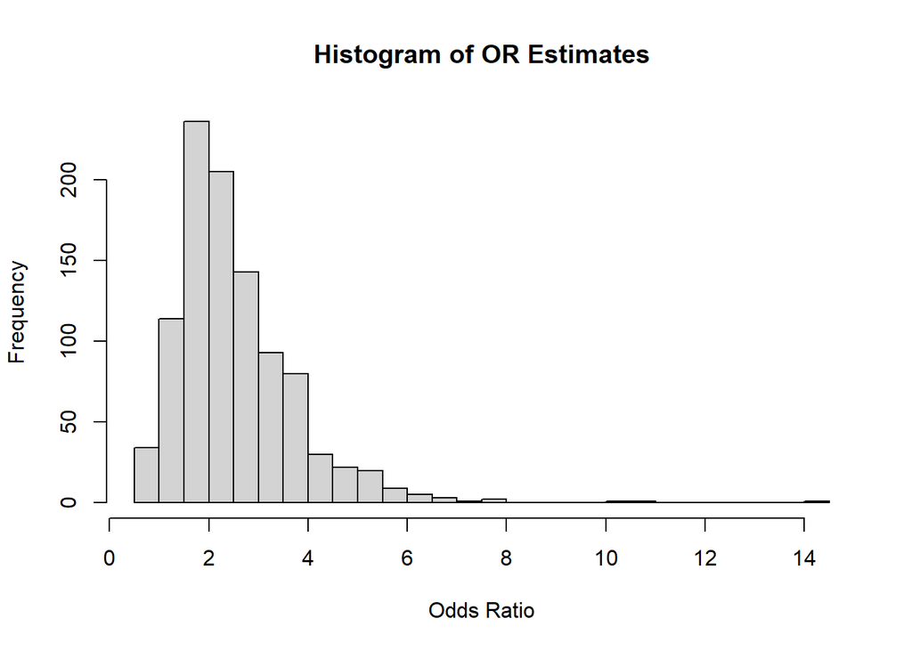

```r
or_estimates <- numeric(num_simulations)

#Генерация однократной выборки и сохранение точечной оценки отношения шансов

for (i in 1:num_simulations) {
  sample_size <- 100
  df_trial <- data.frame(
    arm = rep(c('R', 'T'), each = sample_size),
    patient_ID = rep(1:sample_size, 2),
    recovery_status = c(sample(c(1, 0), sample_size, replace = TRUE, prob = c(p_R, 1 - p_R)),
                        sample(c(1, 0), sample_size, replace = TRUE, prob = c(p_T, 1 - p_T)))
  )

  #Вычисление и сохранение точечной оценки отношения шансов

  df_OR <- df_trial %>%
    dplyr::summarise(broom::tidy(fisher.test(table(.$arm, .$recovery_status))))

  or_estimates[i] <- df_OR$estimate
}

#Построение гистограммы

hist(or_estimates, main="Histogram of OR Estimates", xlab="Odds Ratio", breaks=30)
```

Гистограмма точечных оценок отношения шансов имеет положительную асимметрию, что видно по длинному хвосту, тянущемуся вправо. Большинство оценок сосредоточены в левой части гистограммы, но есть некоторое количество значительно больших оценок, которые создают длинный хвост.Мода соответствует значению OR = 2. Есть значительный разброс в оценках отношения шансов, отраженный в ширине основания гистограммы.

- Проверить, корректно ли работает методика построения ДИ, реализованная в fisher.test, при различных значениях p_R и p_T

```r
check_coverage_OR <- function(p_R, p_T, num_simulations) {
  count_catch <- 0 # счетчик попаданий истинного значения в ДИ
  true_OR <- (p_T / (1 - p_T)) / (p_R / (1 - p_R)) # истинное отношение шансов

  for (i in 1:num_simulations) {
    # генерация выборки
    sample_size <- 100
    df_trial <- data.frame(
      arm = rep(c('R', 'T'), each = sample_size),
      recovery_status = c(sample(c(1, 0), sample_size, replace = TRUE, prob = c(p_R, 1 - p_R)),
                          sample(c(1, 0), sample_size, replace = TRUE, prob = c(p_T, 1 - p_T)))
    )

    # Проверяем, есть ли в каждой группе как минимум одно событие и одно несобытие

    if (all(df_trial$recovery_status[df_trial$arm == 'R'] == 0) || all(df_trial$recovery_status[df_trial$arm == 'R'] == 1) ||
        all(df_trial$recovery_status[df_trial$arm == 'T'] == 0) || all(df_trial$recovery_status[df_trial$arm == 'T'] == 1)) {
      next # Пропускаем итерацию, если условие не выполняется
    }

    # Если данные подходят, выполняем тест Фишера
    test_result <- fisher.test(table(df_trial$arm, df_trial$recovery_status))

    # Проверяем, попадает ли истинное OR в построенный ДИ
    if (test_result$conf.int[1] < true_OR && true_OR < test_result$conf.int[2]) {
      count_catch <- count_catch + 1
    }
  }

  # Возвращаем долю попаданий
  return(count_catch / num_simulations)
}

# Задаем различные значения p_R и p_T
p_values <- seq(0.0, 1.0, by = 0.1)
num_simulations <- 100


# Создаем матрицу для результатов
coverage_matrix <- matrix(nrow = length(p_values), ncol = length(p_values))

# Заполняем матрицу результатами покрытия
for (i in 1:length(p_values)) {
  for (j in 1:length(p_values)) {
    coverage_matrix[i, j] <- check_coverage_OR(p_values[i], p_values[j], num_simulations)
  }
}

# Преобразуем матрицу в датафрейм для наглядности
coverage_df <- expand.grid(p_R = p_values, p_T = p_values)
coverage_df$Coverage <- as.vector(coverage_matrix)

# Выводим датафрейм с результатами
print(coverage_df)
```

```
##     p_R p_T Coverage
## 1   0.0 0.0     0.00
## 2   0.1 0.0     0.00
## 3   0.2 0.0     0.00
## 4   0.3 0.0     0.00
## 5   0.4 0.0     0.00
## 6   0.5 0.0     0.00
## 7   0.6 0.0     0.00
## 8   0.7 0.0     0.00
## 9   0.8 0.0     0.00
## 10  0.9 0.0     0.00
## 11  1.0 0.0     0.00
## 12  0.0 0.1     0.00
## 13  0.1 0.1     0.96
## 14  0.2 0.1     0.98
```

[output cut: 107 more lines]

Отлично, в результатах есть покрытие, равное нуля.Посмотрим где это происходит:

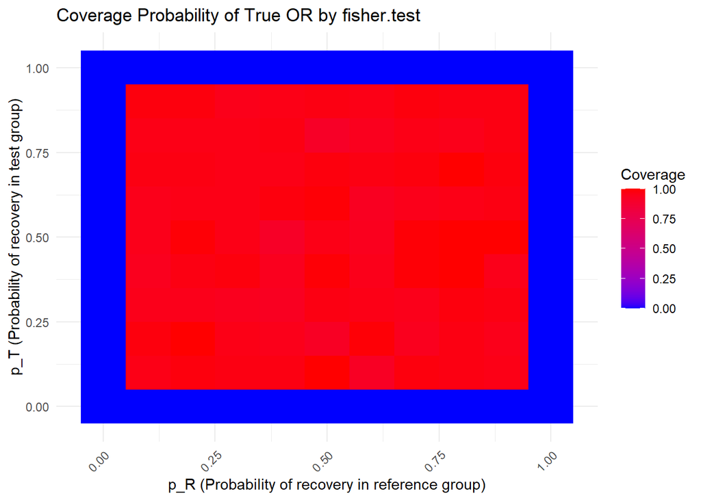

```r
# Создаем график
ggplot(coverage_df, aes(x = p_R, y = p_T, fill = Coverage)) +
  geom_tile() +
  scale_fill_gradient(low = "blue", high = "red") +
  labs(title = "Coverage Probability of True OR by fisher.test",
       x = "p_R (Probability of recovery in reference group)",
       y = "p_T (Probability of recovery in test group)",
       fill = "Coverage") +
  theme_minimal() + # Используем минималистичную тему
  theme(axis.text.x = element_text(angle = 45, hjust = 1))
```